# BioInfo_KCrossVal_LogReg_Updated

Charles Marks

1/21/2019

## Loading the Dataset

This dataset was produced from UCSD EHR records :

```r
df <- read.csv("final_dataset.csv", header=TRUE)
```

## table one

Here is the descriptive statistics, stratified by history of glaucoma surgery. Rows from this can be taken to present a final descriptive table, if so desired. Descriptive table might not be overly meaningful tho…

```r
tone_vars = colnames(clean_data)
tone_vars[12] <- NA
tone_vars[28] <- NA
tone <- tableone::CreateTableOne(vars = tone_vars, strata = c("any_glaucoma_surgey") ,data =  clean_data)

tone_df <- print(tone, printToggle = FALSE, noSpaces = TRUE)

kable(tone_df) %>%
  kable_styling(bootstrap_options = "striped", full_width = F)
```

|  | No | Yes | p | test |
| --- | --- | --- | --- | --- |
| n | 211 | 174 |  |  |
| X (mean (sd)) | 452.96 (298.26) | 375.66 (239.24) | 0.006 |  |
| Age (mean (sd)) | 73.24 (11.88) | 73.09 (12.60) | 0.905 |  |
| Gender = Male (%) | 98 (46.4) | 89 (51.1) | 0.414 |  |
| Race (%) |  |  | NaN |  |
| American Indian or Alaska Native | 0 (0.0) | 1 (0.6) |  |  |
| Asian | 29 (13.7) | 20 (11.5) |  |  |
| Black or African American | 7 (3.3) | 16 (9.2) |  |  |
| Native Hawaiian or Other Pacific Islander | 0 (0.0) | 0 (0.0) |  |  |
| NULL | 1 (0.5) | 0 (0.0) |  |  |
| Other Race or Mixed Race | 36 (17.1) | 33 (19.0) |  |  |
| Unknown (Patient cannot or refuses to declare race) | 16 (7.6) | 12 (6.9) |  |  |
| White | 122 (57.8) | 92 (52.9) |  |  |
| Ethnicity (%) |  |  | NaN |  |
| African American | 0 (0.0) | 1 (0.6) |  |  |
| Asian/Pacific Islander | 0 (0.0) | 1 (0.6) |  |  |
| Caucasian | 1 (0.5) | 0 (0.0) |  |  |
| Hispanic | 32 (15.2) | 25 (14.4) |  |  |
| Hispanic/Latino | 1 (0.5) | 2 (1.1) |  |  |
| Multi-Racial | 1 (0.5) | 2 (1.1) |  |  |
| Non-Hispanic | 156 (73.9) | 128 (73.6) |  |  |
| NULL | 0 (0.0) | 0 (0.0) |  |  |
| Unknown (Patient cannot or refuses to declare ethnicity) | 20 (9.5) | 15 (8.6) |  |  |
| any_glaucoma_surgey = Yes (%) | 0 (0.0) | 174 (100.0) | <0.001 |  |
| incisional_glaucoma_surgery = Yes (%) | 0 (0.0) | 158 (90.8) | <0.001 |  |
| min_invasive_glaucoma_surgery = Yes (%) | 0 (0.0) | 29 (16.7) | <0.001 |  |
| laser_glaucoma_surgery = Yes (%) | 0 (0.0) | 158 (90.8) | <0.001 |  |
| surgery_count (mean (sd)) | 0.00 (0.00) | 3.98 (2.06) | <0.001 |  |
| systolic_max (mean (sd)) | 152.14 (21.76) | 153.99 (19.71) | 0.385 |  |
| systolic_min (mean (sd)) | 118.75 (22.66) | 115.02 (17.12) | 0.074 |  |

[output cut: 153 more lines]

## Bivariate Associations

```r
bi.final <- data.frame(matrix(nrow = 0, ncol = 3))## create a table for bivariate results

for(i in 3:ncol(clean_data))
{
  iv <- colnames(clean_data)[i]  # gets the variable name for the column
  possibleError <- tryCatch( # we need to check for an error because the column data may not be regressable (ie only one value for the variable for all participants)
    bi.model <- glm (any_glaucoma_surgey ~ get(iv), data = clean_data, family = binomial(link="logit")), error = function(e) e
  )

  if(!inherits(possibleError, "error")){

    possibleError2 <- tryCatch(bi.results <- exp(cbind(OR = coef(bi.model), confint(bi.model))), error = function(e) e) ## similar error check
    if(!inherits(possibleError2, "error")){
      rownames(bi.results)[2] <- colnames(clean_data)[i]
      bi.final <- rbind(bi.final, bi.results)
    }
  }

}
# this table represents all variables found to be significant and their OR
bi.signif <- bi.final[which(bi.final$`2.5 %` > 1 | bi.final$`97.5 %`<1),]

kable(bi.final) %>%
  kable_styling(bootstrap_options = "striped", full_width = F)
```

|  | OR | 2.5 % | 97.5 % |
| --- | --- | --- | --- |
| (Intercept) | 0.888 | 0.259 | 3.017 |
| Age | 0.999 | 0.983 | 1.016 |
| (Intercept)1 | 0.752 | 0.566 | 0.995 |
| Gender | 1.207 | 0.808 | 1.806 |
| (Intercept)2 | 2118179.977 | 0.000 | NA |
| Race | 0.000 | NA | 419440168852871591824973544014147299942673210780428194428985730878406656.000 |
| get(iv)Black or African American | 0.000 | NA | 1266025413530807216685073393091397158489895573466422537444048382826905600.000 |
| get(iv)NULL | 0.000 | NA | 2993253440538865912348541673644477435796939605123074557889557464623349760.000 |
| get(iv)Other Race or Mixed Race | 0.000 | NA | 567573307783974232672630176880011314357758508014690968571149932172410880.000 |
| get(iv)Unknown (Patient cannot or refuses to declare race) | 0.000 | NA | 437321280753973360169769852724908447796680219496308949802767940218519552.000 |
| get(iv)White | 0.000 | NA | 479779479216364397512820048263454916848588852064111100144242180420009984.000 |
| (Intercept)3 | 2118179.977 | 0.000 | NA |
| Ethnicity | 1.000 | 0.000 | 13171711681.143 |
| get(iv)Caucasian | 0.000 | NA | 2993255326416361981821228518562429072060029650865645526775880141902970880.000 |
| get(iv)Hispanic | 0.000 | NA | 479407026070523186545333840286646384149572123577154211809017154301329408.000 |
| get(iv)Hispanic/Latino | 0.000 | NA | 423830564870464202086519990123278281290077753698899558846693376.000 |
| get(iv)Multi-Racial | 0.000 | NA | 8290339502813258260251877515428480586824020632589565952.000 |
| get(iv)Non-Hispanic | 0.000 | NA | 523794363492252586273133166089400155491916471605421806018402837650735104.000 |
| get(iv)Unknown (Patient cannot or refuses to declare ethnicity) | 0.000 | NA | 446123810039022431062693272983479907467510166761875967169068704315998208.000 |
| (Intercept)4 | 0.000 | 0.000 | 0.000 |
| any_glaucoma_surgey | 118848073078700551176192.000 | Inf | Inf |
| (Intercept)5 | 0.076 | 0.044 | 0.122 |
| incisional_glaucoma_surgery | 11269186171.633 | 501828767720282068207347217876482703089104037114428975659547…… | 157263374590791694519260375027321340002842802950622074232896…… |
| (Intercept)6 | 0.687 | 0.555 | 0.848 |
| min_invasive_glaucoma_surgery | 61910037.243 | 0.000 | 3865226538714710376545412819716044852733799775061074181268889827376956944719184683186617715047530496.000 |
| (Intercept)7 | 0.076 | 0.044 | 0.122 |
| laser_glaucoma_surgery | 11269186171.633 | 501828767720282068207347217876482703089104037114428975659547…… | 157263374590791694519260375027321340002842802950622074232896…… |
| (Intercept)8 | 0.000 | 0.000 | 0.000 |
| surgery_count | 21408734301954297856.000 | Inf | Inf |
| (Intercept)9 | 0.428 | 0.095 | 1.897 |

[output cut: 555 more lines]

```r
kable(bi.signif)  %>%
  kable_styling(bootstrap_options = "striped", full_width = F)
```

|  | OR | 2.5 % | 97.5 % |
| --- | --- | --- | --- |
| (Intercept)1 | 0.752 | 0.566 | 0.995 |
| (Intercept)4 | 0.000 | 0.000 | 0.000 |
| any_glaucoma_surgey | 118848073078700551176192.000 | Inf | Inf |
| (Intercept)5 | 0.076 | 0.044 | 0.122 |
| incisional_glaucoma_surgery | 11269186171.633 | 501828767720282068207347217876482703089104037114428975659547…… | 157263374590791694519260375027321340002842802950622074232896…… |
| (Intercept)6 | 0.687 | 0.555 | 0.848 |
| (Intercept)7 | 0.076 | 0.044 | 0.122 |
| laser_glaucoma_surgery | 11269186171.633 | 501828767720282068207347217876482703089104037114428975659547…… | 157263374590791694519260375027321340002842802950622074232896…… |
| (Intercept)8 | 0.000 | 0.000 | 0.000 |
| surgery_count | 21408734301954297856.000 | Inf | Inf |
| vital_entries | 0.995 | 0.989 | 0.999 |
| (Intercept)27 | 0.810 | 0.662 | 0.991 |
| (Intercept)34 | 0.805 | 0.657 | 0.985 |
| (Intercept)37 | 0.808 | 0.655 | 0.995 |
| days_hospitalized | 0.983 | 0.966 | 0.997 |
| med_class.Analgesics_._non.opioids | 0.242 | 0.102 | 0.512 |
| (Intercept)57 | 0.809 | 0.655 | 0.998 |
| med_class.Antidepressants | 0.493 | 0.262 | 0.895 |
| med_class.Antihyperlipidemic | 0.619 | 0.382 | 0.991 |
| (Intercept)71 | 0.813 | 0.663 | 0.995 |
| med_class.Antipsychotics | 0.291 | 0.066 | 0.934 |
| med_class.Antiviral | 0.268 | 0.088 | 0.673 |
| med_class.Decongestants | 0.527 | 0.274 | 0.977 |
| med_class.Hematopoietic_agents | 0.424 | 0.162 | 0.990 |
| med_class.Misc._antiinfectives | 0.425 | 0.182 | 0.910 |
| med_class.Misc._psychotherapeutic | 0.168 | 0.009 | 0.959 |
| (Intercept)111 | 1.398 | 1.056 | 1.857 |
| med_class.Ophthalmic | 0.324 | 0.212 | 0.491 |
| (Intercept)123 | 0.811 | 0.659 | 0.996 |
| (Intercept)135 | 0.125 | 0.023 | 0.554 |
| iron | 1.020 | 1.002 | 1.040 |
| (Intercept)136 | 0.250 | 0.056 | 0.973 |
| (Intercept)140 | 0.728 | 0.543 | 0.971 |
| (Intercept)142 | 0.272 | 0.090 | 0.782 |
| (Intercept)148 | 0.380 | 0.155 | 0.856 |

## Logisitc Regression 5-Fold Cross Validation

So, we are going to run the 5-fold cross val 100 times and return the results (mean AUC, SD). We shall utilize a bi-directional stepwise logistic regression function to run the analyses on 80% of the data set and then predict on the other fifth of the data set

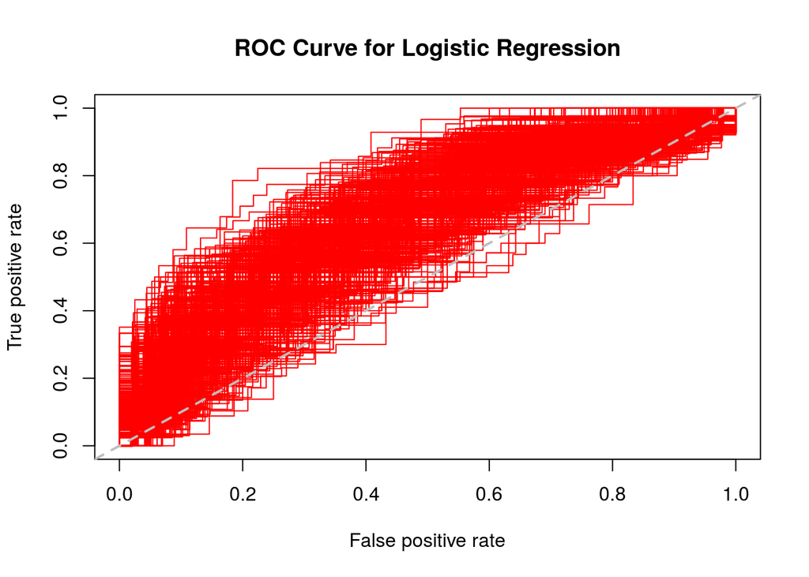

```r
runfold <- function(train, test)
{

  model.null = glm(any_glaucoma_surgey ~ 1,
                 data=train,
                 family = binomial(link="logit")
                 )

  model.full= glm(any_glaucoma_surgey ~ Age + Gender +systolic_max + systolic_min + systolic_mean  + diastolic_max + diastolic_min + diastolic_mean +pulse_min + pulse_max + pulse_mean  +ever_hospitalized + days_hospitalized + CHF + PVD + Stroke + Dementia + Pulmonary + LiverMild + DM + DMcx  + Renal + Cancer + Mets + med_class.Analgesics_._non.opioids + med_class.Analgesics_._opioids  +  med_class.Anti.rheumatic +  med_class.Antianxiety_agents  + med_class.Antiasthmatic + med_class.Anticoagulants + med_class.Anticonvulsant + med_class.Antidepressants + med_class.Antidiabetic + med_class.Antiemetics + med_class.Antihyperlipidemic + med_class.Antihypertensive + med_class.Beta_blockers + med_class.Calcium_blockers + med_class.Corticosteroids + med_class.Cough.Cold + med_class.Decongestants + med_class.Dermatological + med_class.Diuretics + med_class.Laxatives + med_class.Macrolide_antibiotics + med_class.Misc._antiinfectives + med_class.Ophthalmic+med_class.Ulcer_drugs,
                 data=train,
                 family = binomial(link="logit")
                 )

  step.results <- step(model.null,
     scope = list(upper=model.full),
             direction="both",
             test="Chisq",
             data=train, trace = 0)

  final.model <- eval(step.results$call)
  lr.pr <- predict(final.model, test, type="response") # this sequence used to plot the ROC Curve
  lr.pred <- ROCR::prediction(lr.pr,test$any_glaucoma_surgey)

  auc_curve <- ROCR::performance(lr.pred,"tpr","fpr")

  auc <- ROCR::performance(lr.pred,"auc")@y.values[[1]]

  return(list(auc,auc_curve))
}

## this function will randomize the data into five even groups and run
## the cross validations, returning an average AUC and the AUC curves
## of each of the cross validations
fivefold <- function(data){

#create a vector with the appropriate number of 1,2,3,4,5
values <- rep(1:5, length.out=nrow(data))
#randomly sort this vector
random <- sample(values)
#add this vector to the data, essentially assigning each row a random group
data$cv_group <- random


## next we want to assign the five test and training pairings
train.one <- data[which(data$cv_group!= 1),]
test.one <- data[which(data$cv_group== 1),]
train.two <- data[which(data$cv_group!= 2),]
test.two <- data[which(data$cv_group== 2),]
train.three <- data[which(data$cv_group!= 3),]
test.three <- data[which(data$cv_group== 3),]
train.four <- data[which(data$cv_group!= 4),]
test.four <- data[which(data$cv_group== 4),]
train.five <- data[which(data$cv_group!= 5),]
test.five <- data[which(data$cv_group== 5),]

res1 <- runfold(train.one, test.one)
res2 <- runfold(train.two, test.two)
res3 <- runfold(train.three, test.three)
res4 <- runfold(train.four, test.four)
res5 <- runfold(train.five, test.five)


aucs <- c(res1[1][[1]],res2[1][[1]],res3[1][[1]],res4[1][[1]],res5[1][[1]])
auc_curves <- list(res1[2][[1]],res2[2][[1]],res3[2][[1]],res4[2][[1]],res5[2][[1]])

#plot(res1[2][[1]])
#plot(res2[2][[1]], add = TRUE)
return(list(aucs, auc_curves))

}

auc_curves <- list()
mean_aucs <- c()

for(i in 1:100){
  kfold_result <- fivefold(clean_data)

  mean_aucs <- c(mean_aucs, mean(kfold_result[[1]]))

  for(j in 1:5)
  {
    auc_curves <- append(auc_curves, kfold_result[[2]][[j]])
  }

}

count <- 0
evaluation_string <- ""
for (i in 1:length(auc_curves)) {
  if(count == 0)
  {
    new_string <- paste("plot(auc_curves[[",i,"]],main='ROC Curve for Logistic Regression',col=2,lwd=2)", sep ="")
    evaluation_string <- new_string
    count <- 1
  } else {
    new_string <- paste("plot(auc_curves[[",i,"]], add = TRUE, col = 2)", sep ="")
    evaluation_string <- paste(evaluation_string, new_string, sep = "\n")
  }
}

evaluation_string <- paste(evaluation_string, "abline(a=0,b=1,lwd=2,lty=2,col='gray')", sep ="\n")


eval(parse(text=evaluation_string))
```

```r
paste("The mean AUC of the models: ", mean(mean_aucs), sep = "")
```

```
## [1] "The mean AUC of the models: 0.662114001667911"
```

```r
paste("The SD of AUCs of the models: ", sd(mean_aucs), sep = "")
```

```
## [1] "The SD of AUCs of the models: 0.01611994693577"
```

### Running Stepwise Log Reg

As well, we want to just report the logisitc regression results of the entire data set

```r
model.null = glm(any_glaucoma_surgey ~ 1,
                 data=clean_data,
                 family = binomial(link="logit")
                 )

  model.full= glm(any_glaucoma_surgey ~ Age + Gender +systolic_max + systolic_min + systolic_mean  + diastolic_max + diastolic_min + diastolic_mean +pulse_min + pulse_max + pulse_mean  +ever_hospitalized + days_hospitalized + CHF + PVD + Stroke + Dementia + Pulmonary + LiverMild + DM + DMcx  + Renal + Cancer + Mets + med_class.Analgesics_._non.opioids + med_class.Analgesics_._opioids  +  med_class.Anti.rheumatic +  med_class.Antianxiety_agents  + med_class.Antiasthmatic + med_class.Anticoagulants + med_class.Anticonvulsant + med_class.Antidepressants + med_class.Antidiabetic + med_class.Antiemetics + med_class.Antihyperlipidemic + med_class.Antihypertensive + med_class.Beta_blockers + med_class.Calcium_blockers + med_class.Corticosteroids + med_class.Cough.Cold + med_class.Decongestants + med_class.Dermatological + med_class.Diuretics + med_class.Laxatives + med_class.Macrolide_antibiotics + med_class.Misc._antiinfectives + med_class.Ophthalmic+med_class.Ulcer_drugs,
                 data=clean_data,
                 family = binomial(link="logit")
                 )

  step.results <- step(model.null,
     scope = list(upper=model.full),
             direction="both",
             test="Chisq",
             data=clean_data, trace = 0)

  final.model <- eval(step.results$call)

  results <- exp(cbind(OR = coef(final.model), confint(final.model)))

  kable(results) %>%
  kable_styling(bootstrap_options = "striped", full_width = F)
```

|  | OR | 2.5 % | 97.5 % |
| --- | --- | --- | --- |
| (Intercept) | 1.647 | 0.174 | 15.914 |
| med_class.OphthalmicYes | 0.280 | 0.170 | 0.455 |
| med_class.Analgesics_._non.opioidsYes | 0.205 | 0.072 | 0.522 |
| systolic_min | 0.923 | 0.894 | 0.951 |
| systolic_mean | 1.089 | 1.055 | 1.127 |
| days_hospitalized | 0.968 | 0.943 | 0.989 |
| med_class.AntihyperlipidemicYes | 0.392 | 0.207 | 0.730 |
| med_class.AntidepressantsYes | 0.560 | 0.254 | 1.210 |
| med_class.Calcium_blockersYes | 0.433 | 0.205 | 0.893 |
| med_class.AnticoagulantsYes | 2.746 | 1.049 | 7.464 |
| MetsYes | 0.312 | 0.056 | 1.430 |
| med_class.Macrolide_antibioticsYes | 0.398 | 0.167 | 0.927 |
| med_class.Cough.ColdYes | 2.216 | 0.828 | 6.062 |
| GenderMale | 1.520 | 0.941 | 2.472 |
| diastolic_min | 0.977 | 0.948 | 1.006 |
| DementiaYes | 0.261 | 0.035 | 1.383 |

## Random Forests CrossVal

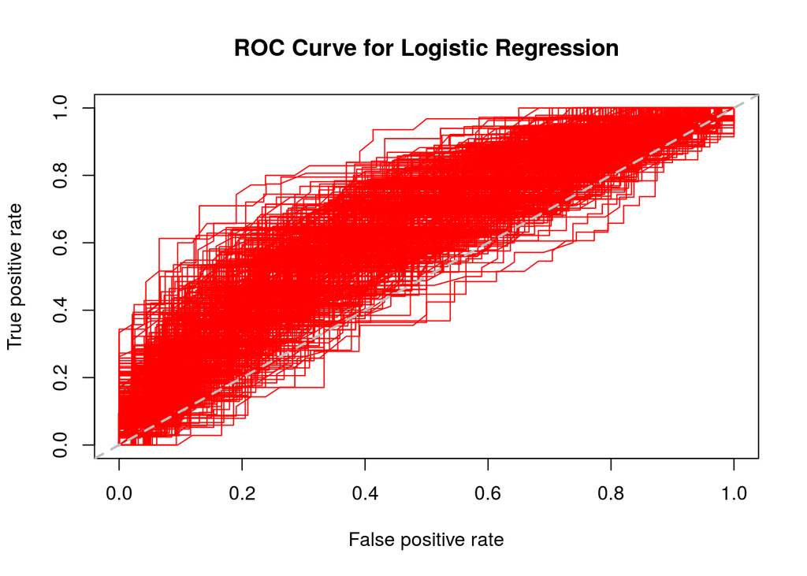

```r
runfold_rf <- function(train, test)
{

  model.rf = randomForest(any_glaucoma_surgey ~ Age + Gender +systolic_max + systolic_min + systolic_mean  + diastolic_max + diastolic_min + diastolic_mean +pulse_min + pulse_max + pulse_mean  +ever_hospitalized + days_hospitalized + CHF + PVD + Stroke + Dementia + Pulmonary + LiverMild + DM + DMcx  + Renal + Cancer + Mets + med_class.Analgesics_._non.opioids + med_class.Analgesics_._opioids  +  med_class.Anti.rheumatic +  med_class.Antianxiety_agents  + med_class.Antiasthmatic + med_class.Anticoagulants + med_class.Anticonvulsant + med_class.Antidepressants + med_class.Antidiabetic + med_class.Antiemetics + med_class.Antihyperlipidemic + med_class.Antihypertensive + med_class.Beta_blockers + med_class.Calcium_blockers + med_class.Corticosteroids + med_class.Cough.Cold + med_class.Decongestants + med_class.Dermatological + med_class.Diuretics + med_class.Laxatives + med_class.Macrolide_antibiotics + med_class.Misc._antiinfectives + med_class.Ophthalmic + med_class.Ulcer_drugs,
                 data=train, importance = TRUE, mtry = 6
                 )

  pr <- predict(model.rf, test, type="prob")[,2] # this sequence used to plot the ROC Curve
  pred <- ROCR::prediction(pr,test$any_glaucoma_surgey)

  auc_curve <- ROCR::performance(pred,"tpr","fpr")

  auc <- ROCR::performance(pred,"auc")@y.values[[1]]

  return(list(auc,auc_curve))
}

## this function will randomize the data into five even groups and run
## the cross validations, returning an average AUC and the AUC curves
## of each of the cross validations
fivefold_rf <- function(data){

#create a vector with the appropriate number of 1,2,3,4,5
values <- rep(1:5, length.out=nrow(data))
#randomly sort this vector
random <- sample(values)
#add this vector to the data, essentially assigning each row a random group
data$cv_group <- random


## next we want to assign the five test and training pairings
train.one <- data[which(data$cv_group!= 1),]
test.one <- data[which(data$cv_group== 1),]
train.two <- data[which(data$cv_group!= 2),]
test.two <- data[which(data$cv_group== 2),]
train.three <- data[which(data$cv_group!= 3),]
test.three <- data[which(data$cv_group== 3),]
train.four <- data[which(data$cv_group!= 4),]
test.four <- data[which(data$cv_group== 4),]
train.five <- data[which(data$cv_group!= 5),]
test.five <- data[which(data$cv_group== 5),]

res1 <- runfold_rf(train.one, test.one)
res2 <- runfold_rf(train.two, test.two)
res3 <- runfold_rf(train.three, test.three)
res4 <- runfold_rf(train.four, test.four)
res5 <- runfold_rf(train.five, test.five)


aucs <- c(res1[1][[1]],res2[1][[1]],res3[1][[1]],res4[1][[1]],res5[1][[1]])
auc_curves <- list(res1[2][[1]],res2[2][[1]],res3[2][[1]],res4[2][[1]],res5[2][[1]])

#plot(res1[2][[1]])
#plot(res2[2][[1]], add = TRUE)
return(list(aucs, auc_curves))

}

auc_curves <- list()
mean_aucs <- c()

for(i in 1:100){
  kfold_result <- fivefold_rf(clean_data)

  mean_aucs <- c(mean_aucs, mean(kfold_result[[1]]))

  for(j in 1:5)
  {
    auc_curves <- append(auc_curves, kfold_result[[2]][[j]])
  }

}

count <- 0
evaluation_string <- ""
for (i in 1:length(auc_curves)) {
  if(count == 0)
  {
    new_string <- paste("plot(auc_curves[[",i,"]],main='ROC Curve for Logistic Regression',col=2,lwd=2)", sep ="")
    evaluation_string <- new_string
    count <- 1
  } else {
    new_string <- paste("plot(auc_curves[[",i,"]], add = TRUE, col = 2)", sep ="")
    evaluation_string <- paste(evaluation_string, new_string, sep = "\n")
  }
}

evaluation_string <- paste(evaluation_string, "abline(a=0,b=1,lwd=2,lty=2,col='gray')", sep ="\n")


eval(parse(text=evaluation_string))
```

```r
paste("The mean AUC of the models: ", mean(mean_aucs), sep = "")
```

```
## [1] "The mean AUC of the models: 0.646826596193498"
```

```r
paste("The SD of AUCs of the models: ", sd(mean_aucs), sep = "")
```

```
## [1] "The SD of AUCs of the models: 0.015910445669384"
```

### Random Forests Importance Scores

```r
  model.rf = randomForest(any_glaucoma_surgey ~ Age + Gender +systolic_max + systolic_min + systolic_mean  + diastolic_max + diastolic_min + diastolic_mean +pulse_min + pulse_max + pulse_mean  +ever_hospitalized + days_hospitalized + CHF + PVD + Stroke + Dementia + Pulmonary + LiverMild + DM + DMcx  + Renal + Cancer + Mets + med_class.Analgesics_._non.opioids + med_class.Analgesics_._opioids  +  med_class.Anti.rheumatic +  med_class.Antianxiety_agents  + med_class.Antiasthmatic + med_class.Anticoagulants + med_class.Anticonvulsant + med_class.Antidepressants + med_class.Antidiabetic + med_class.Antiemetics + med_class.Antihyperlipidemic + med_class.Antihypertensive + med_class.Beta_blockers + med_class.Calcium_blockers + med_class.Corticosteroids + med_class.Cough.Cold + med_class.Decongestants + med_class.Dermatological + med_class.Diuretics + med_class.Laxatives + med_class.Macrolide_antibiotics + med_class.Misc._antiinfectives + med_class.Ophthalmic + med_class.Ulcer_drugs,
                 data=clean_data, importance = TRUE, mtry = 6
                 )

results <- importance(model.rf)

 kable(results) %>%
  kable_styling(bootstrap_options = "striped", full_width = F)
```

|  | No | Yes | MeanDecreaseAccuracy | MeanDecreaseGini |
| --- | --- | --- | --- | --- |
| Age | 0.907 | 1.836 | 1.941 | 11.792 |
| Gender | -2.360 | -4.035 | -4.683 | 2.075 |
| systolic_max | 2.094 | 0.280 | 1.814 | 12.240 |
| systolic_min | 11.541 | -2.826 | 8.181 | 14.069 |
| systolic_mean | 0.059 | -1.505 | -1.115 | 13.044 |
| diastolic_max | 4.984 | 0.379 | 4.433 | 12.323 |
| diastolic_min | 6.094 | -0.235 | 4.993 | 11.565 |
| diastolic_mean | -1.231 | -0.240 | -1.022 | 11.864 |
| pulse_min | 3.930 | 0.602 | 3.419 | 11.656 |
| pulse_max | 4.621 | 1.183 | 4.448 | 12.303 |
| pulse_mean | 0.175 | 3.765 | 3.067 | 13.150 |
| ever_hospitalized | 0.860 | -1.119 | -0.301 | 1.015 |
| days_hospitalized | 6.019 | 1.033 | 5.797 | 10.184 |
| CHF | -2.760 | 1.623 | -1.310 | 0.559 |
| PVD | -0.903 | 1.131 | 0.195 | 0.926 |
| Stroke | -1.444 | -1.478 | -2.166 | 0.729 |
| Dementia | 0.914 | -2.519 | -0.916 | 0.519 |
| Pulmonary | 0.582 | 0.941 | 1.191 | 1.482 |
| LiverMild | -2.608 | 1.520 | -0.841 | 0.827 |
| DM | 3.365 | -0.576 | 1.944 | 0.827 |
| DMcx | 1.332 | -2.100 | -0.278 | 0.849 |
| Renal | -1.647 | 0.092 | -1.089 | 1.042 |
| Cancer | 1.157 | -1.032 | 0.340 | 1.108 |
| Mets | 3.203 | 2.249 | 3.482 | 0.751 |
| med_class.Analgesics_._non.opioids | 5.491 | 5.485 | 7.709 | 3.310 |
| med_class.Analgesics_._opioids | -0.433 | 1.235 | 0.527 | 0.984 |
| med_class.Anti.rheumatic | 1.959 | -1.266 | 0.716 | 1.064 |
| med_class.Antianxiety_agents | -0.150 | -0.708 | -0.586 | 0.675 |
| med_class.Antiasthmatic | 3.272 | -3.097 | 0.951 | 1.014 |
| med_class.Anticoagulants | 0.664 | 0.165 | 0.651 | 0.882 |
| med_class.Anticonvulsant | 1.171 | -0.617 | 0.456 | 0.966 |
| med_class.Antidepressants | 5.129 | -0.221 | 3.781 | 1.705 |
| med_class.Antidiabetic | -1.224 | -1.255 | -1.747 | 0.773 |
| med_class.Antiemetics | 0.445 | 0.056 | 0.484 | 1.122 |
| med_class.Antihyperlipidemic | 0.490 | 1.448 | 1.421 | 1.839 |
| med_class.Antihypertensive | 1.298 | 0.255 | 1.221 | 1.357 |
| med_class.Beta_blockers | -1.508 | 2.037 | 0.369 | 1.001 |
| med_class.Calcium_blockers | 3.802 | -0.702 | 2.649 | 1.554 |
| med_class.Corticosteroids | -1.013 | -1.154 | -1.489 | 0.844 |
| med_class.Cough.Cold | -1.456 | -1.311 | -2.011 | 0.700 |
| med_class.Decongestants | 1.401 | 0.016 | 1.107 | 1.425 |
| med_class.Dermatological | 0.603 | 2.711 | 2.280 | 1.702 |
| med_class.Diuretics | 1.548 | 1.113 | 1.930 | 1.198 |
| med_class.Laxatives | 2.673 | -1.528 | 1.333 | 1.163 |
| med_class.Macrolide_antibiotics | 1.095 | -0.171 | 0.501 | 1.102 |
| med_class.Misc._antiinfectives | 0.842 | 2.067 | 2.367 | 1.067 |
| med_class.Ophthalmic | 6.702 | 7.148 | 9.284 | 8.866 |
| med_class.Ulcer_drugs | 1.031 | 1.436 | 2.134 | 1.168 |

### Make Numeric Data Set

To Run ANN you have to use a numeric data set and everything need to be scaled as well

```r
#first scale the data
numeric_data <- clean_data
for(i in 1:ncol(numeric_data)) # this loop goes through all of the variables and makes the non-numeric data numeric
{
  if(!is.numeric(numeric_data[,i]))
  {
    numeric_data[,i] <- as.numeric(numeric_data[,i])
  }


}
# these three lines scale all of the data frame
max <- apply(numeric_data,2,max)
min <- apply(numeric_data,2,min)
numeric_data <- as.data.frame(scale(numeric_data, center = min, scale = max - min))
```

### Run the CrossVal

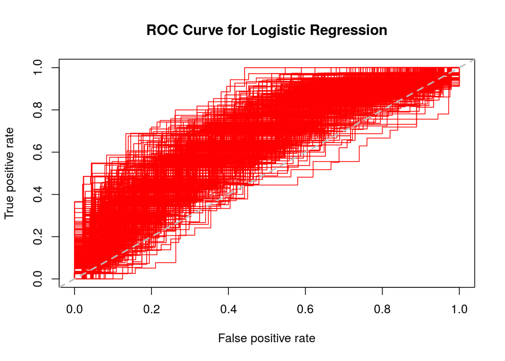

```r
runfold_ann <- function(train, test)
{

  model.ann <- neuralnet(any_glaucoma_surgey ~ Age + Gender +systolic_max + systolic_min + systolic_mean  + diastolic_max + diastolic_min + diastolic_mean +pulse_min + pulse_max + pulse_mean  +ever_hospitalized + days_hospitalized + CHF + PVD + Stroke + Dementia + Pulmonary + LiverMild + DM + DMcx  + Renal + Cancer + Mets + med_class.Analgesics_._non.opioids + med_class.Analgesics_._opioids  +  med_class.Anti.rheumatic +  med_class.Antianxiety_agents  + med_class.Antiasthmatic + med_class.Anticoagulants + med_class.Anticonvulsant + med_class.Antidepressants + med_class.Antidiabetic + med_class.Antiemetics + med_class.Antihyperlipidemic + med_class.Antihypertensive + med_class.Beta_blockers + med_class.Calcium_blockers + med_class.Corticosteroids + med_class.Cough.Cold + med_class.Decongestants + med_class.Dermatological + med_class.Diuretics + med_class.Laxatives + med_class.Macrolide_antibiotics + med_class.Misc._antiinfectives + med_class.Ophthalmic + med_class.Ulcer_drugs,
                 data=train, hidden = c(32,16), threshold = 0.01
                 )
# so, this next line, we need a dataframe that only contains the variables included in the model, these numbers represent the columns of the data frame of all the variables contained in the model...it's not pretty but it works
test.cv <- test[,c(3,4,13,14,15,17,18,19,30,31,32,36,37,38,39,40,43,44,45,47,48,50,52,53,55,56,61,63,65,66,67,68,69,72,75,76,87,88,94,95,96,97,101,108,110,115,126,136)]
### this line is for reproduction (talk to developer about why this is necessary)test.one.cv <- test.one[,c(4,5,14,15,16,18,19,20,31,32,33,37,38,39,40,41,44,45,46,48,49,51,53,54,56,57,62,64,66,67,68,69,70,73,76,77,88,89,95,96,97,98,102,109,111,116,127,137)]
  prob <- compute(model.ann,test)
  prob.results <- prob$net.result

  pred <- prediction(prob.results,test$any_glaucoma_surgey)

  auc_curve <- performance(pred,"tpr","fpr")

  auc <- performance(pred,"auc")@y.values[[1]]

  return(list(auc,auc_curve))
}

## this function will randomize the data into five even groups and run
## the cross validations, returning an average AUC and the AUC curves
## of each of the cross validations
fivefold_ann <- function(data){

#create a vector with the appropriate number of 1,2,3,4,5
values <- rep(1:5, length.out=nrow(data))
#randomly sort this vector
random <- sample(values)
#add this vector to the data, essentially assigning each row a random group
data$cv_group <- random


## next we want to assign the five test and training pairings
train.one <- data[which(data$cv_group!= 1),]
test.one <- data[which(data$cv_group== 1),]
train.two <- data[which(data$cv_group!= 2),]
test.two <- data[which(data$cv_group== 2),]
train.three <- data[which(data$cv_group!= 3),]
test.three <- data[which(data$cv_group== 3),]
train.four <- data[which(data$cv_group!= 4),]
test.four <- data[which(data$cv_group== 4),]
train.five <- data[which(data$cv_group!= 5),]
test.five <- data[which(data$cv_group== 5),]

res1 <- runfold_ann(train.one, test.one)
res2 <- runfold_ann(train.two, test.two)
res3 <- runfold_ann(train.three, test.three)
res4 <- runfold_ann(train.four, test.four)
res5 <- runfold_ann(train.five, test.five)


aucs <- c(res1[1][[1]],res2[1][[1]],res3[1][[1]],res4[1][[1]],res5[1][[1]])
auc_curves <- list(res1[2][[1]],res2[2][[1]],res3[2][[1]],res4[2][[1]],res5[2][[1]])

#plot(res1[2][[1]])
#plot(res2[2][[1]], add = TRUE)
return(list(aucs, auc_curves))

}

auc_curves <- list()
mean_aucs <- c()

for(i in 1:100){
  kfold_result <- fivefold(numeric_data)

  mean_aucs <- c(mean_aucs, mean(kfold_result[[1]]))

  for(j in 1:5)
  {
    auc_curves <- append(auc_curves, kfold_result[[2]][[j]])
  }

}

count <- 0
evaluation_string <- ""
for (i in 1:length(auc_curves)) {
  if(count == 0)
  {
    new_string <- paste("plot(auc_curves[[",i,"]],main='ROC Curve for Logistic Regression',col=2,lwd=2)", sep ="")
    evaluation_string <- new_string
    count <- 1
  } else {
    new_string <- paste("plot(auc_curves[[",i,"]], add = TRUE, col = 2)", sep ="")
    evaluation_string <- paste(evaluation_string, new_string, sep = "\n")
  }
}

evaluation_string <- paste(evaluation_string, "abline(a=0,b=1,lwd=2,lty=2,col='gray')", sep ="\n")


eval(parse(text=evaluation_string))
```

```r
paste("The mean AUC of the models: ", mean(mean_aucs), sep = "")
```

```
## [1] "The mean AUC of the models: 0.662652848462219"
```

```r
paste("The SD of AUCs of the models: ", sd(mean_aucs), sep = "")
```

```
## [1] "The SD of AUCs of the models: 0.015614594222804"
```